# 2012 US Campaign Finance Data Visualization

Zhu Shen, Jingyi Liu, Sarangoo Chimgee

Due Date: 03/22/2018

```r
# Load the dataset
load("house_elections.rda")
load("candidates.rda")
load("committees.rda")
load("contributions.rda")
```

```r
# Define the function that convert the state abbreviation and state's full name
state_name <-function(x) {
  state_df <- data.frame(
     abb = state.abb,
     full_name = tolower(state.name))
  if (x %in% state_df$abb){
  index <- as.numeric(which(state_df$abb == x))
  return(as.character(state_df[index,2]))
  }

  if (x %in% state_df$full_name){
  index <- as.numeric(which(state_df$full_name == x))
  return(as.character(state_df[index,1]))
  }
}

# Define the function of making the map
gplot <- function(input) {
  ggplot(data = states, mapping = aes(x = long, y = lat, group = group)) +
  geom_polygon(color = "white", fill = "white") +
  geom_polygon(data = input, aes(fill = input$state_donation)) +
  theme(axis.title = element_blank(),
        axis.text = element_blank(),
        axis.line = element_blank(),
        axis.ticks = element_blank(),
        panel.background = element_blank(),
        panel.grid = element_blank(),
        panel.border = element_blank(),
        text = element_text(size=15, face = "bold", color = "black"))
}
```

```r
# Filter out the candidate data that is only for 2012 elections
# Change the "REP" and "DEM" to "R" and "D" respectively
candidate_2012 <- candidates %>%
  filter(cand_election_yr == 2012) %>%
  mutate(cand_party_affiliation = gsub("REP", "R", cand_party_affiliation),
         cand_party_affiliation = gsub("DEM", "D", cand_party_affiliation),
         cand_state = as.character(cand_state))

# Change the class of the transaction_date to be "Date" and the transaction_amt to be "Numeric"
contributions <- contributions %>%
  mutate(transaction_date = as.Date(transaction_dt, "%m%d%Y"),
         transaction_amt = as.numeric(transaction_amt))

# Normally, presidential election starts the fundraising 15-20 months before the election.
# Conservatively we take all the donation two years before the election into account

# Filter out all committees' contribution that is "Independent expenditure advocating election of candidate"
# There are some 0 and negative amount and we will filter out those values and only consider the positive values
contributions_2012 <- contributions %>%
  filter(transaction_date >= "2010-11-06" & transaction_date <= "2012-11-06") %>%
  filter(transaction_amt > 0 & transaction_type == "24E") %>%
  group_by(cand_id) %>%
  summarize(total_donation = sum(transaction_amt, na.rm =TRUE))

# Full join the contribution and candidate data
candidate_contributions_2012 <- contributions_2012 %>%
  full_join(candidate_2012, by="cand_id")
```

### Introduction

Potential reform in campaign finance system has been discussed these years to reduce the polarization in parties and states contribution. In this project, we attempt to visualize the discrepancy in independent expenditure across parties and states to explore possible reasons behind the polarization and strengthen American democracy.

We analyze the campaign finance data for Republican and Democratic parties across states in the 2012 federal election cycle, only considering independent expenditure transactions from the ‘Contribution by Committee’ dataset.

### Graphs

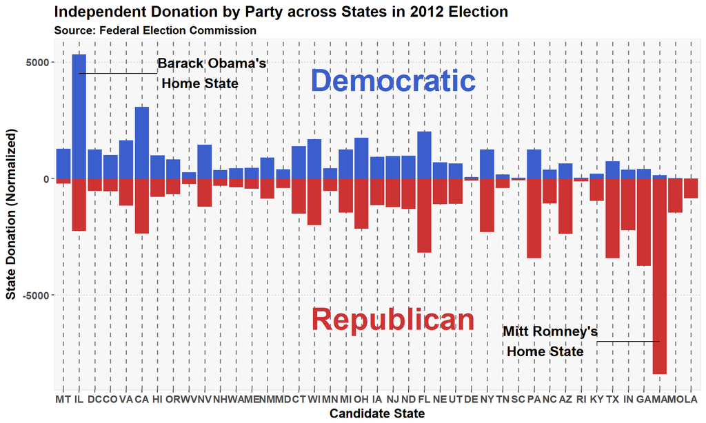

```r
# Only consider the transaction for election year 2012 and all committees' contribution that is "Independent expenditure advocating election of candidate"
contributions_state <- contributions %>%
  filter(transaction_date >= "2011-11-06" & transaction_dt <= "2012-11-06") %>%
  filter(transaction_amt > 0 & transaction_type == "24E")

# Filter out the candidates from Democratic and Republican and for better visualization, we only consider the state with the contribution data for both parties.
# Because some of the contribution amount is extremely large, we normalize the amount for better comparison by taking the square root.
candidate_contributions_state <- contributions_state %>%
  inner_join(candidate_2012, by="cand_id") %>%
  filter(cand_party_affiliation == "R" | cand_party_affiliation == "D") %>%
  group_by(cand_state) %>%
  filter(n_distinct(cand_party_affiliation) == 2) %>%
  group_by(cand_state,cand_party_affiliation) %>%
  summarize(total_donation = sum(transaction_amt)) %>%
  filter(cand_state != "") %>%
  mutate(norm_total_donation = sqrt(total_donation)) %>%
  mutate(norm_total_donation = ifelse(cand_party_affiliation == "R", -1*norm_total_donation, norm_total_donation))

# Build a vector that arrange the name of the state based on the contribution ratio of two parties
cand_list <- candidate_contributions_state %>%
  group_by(cand_state) %>%
  mutate(total_donation_state = sum(abs(norm_total_donation)),
         ratio = norm_total_donation / total_donation_state) %>%
  filter(cand_party_affiliation == "D") %>%
  arrange(desc(ratio)) %>%
  select(cand_state) %>%
  .$cand_state

# Creating the tornado graph with the data, x axis is the state, y axis is the normalized donation and the colors are representative colors for two parties. The bars are arranged based on the ratio of D-contribution to R-contribution from largest to lowest

gg <- ggplot(data = candidate_contributions_state, aes(x = factor(cand_state, level = cand_list), y = norm_total_donation, fill = cand_party_affiliation)) +
        geom_bar(stat="identity", position="identity") +
      theme_bw() +
      theme(axis.line = element_blank(),
            panel.border = element_blank(),
            text = element_text(size=10, face = "bold", color = "black")) +
      labs(title = "Independent Donation by Party across States in 2012 Election",
           subtitle = "Source: Federal Election Commission",
           x = "Candidate State", y = "State Donation (Normalized)") +
      scale_fill_manual(breaks = c("Democratic", "Republican"),
                       values=c("royalblue3","brown3")) +
      theme(text = element_text(colour="black", size=13, face="bold"),
            panel.background = element_rect(fill = "grey97",
                                colour = "grey90",
                                size = 0.5, linetype = "solid"),
            panel.grid.minor.y = element_blank(),
            panel.grid.minor.x = element_blank(),
            panel.grid.major.x = element_line(size=.7, color="grey50", linetype = "dashed"),
            panel.grid.major.y = element_line(size=.3, color="grey70", linetype = "dashed")) +
      annotate(geom="text", x = c("NJ", "NJ"), y = c(4250, -6000),
               label = c("Democratic", "Republican"),
               size = 11, color = c("royalblue3","brown3"), fontface = 'bold') +
      annotate(geom = "segment", x = "IL", xend = "HI", y = 4500, yend = 4500, size = 0.5) +
      annotate(geom = "text", x = "HI", y = 5200, label = "Barack Obama's\n Home State", fontface = "bold", hjust = 0, vjust = 1, size = 5)+
      annotate(geom = "segment", x = "MA", xend = "KY", y = -7000, yend = -7000, size = 0.5) +
      annotate(geom = "text", x = "TN", y = -6300, label = "Mitt Romney's\n Home State", fontface = "bold", hjust = 0, vjust = 1, size = 5)

gg
```

The bar graph shows contributions for two parties across the states in 2012, including states with contribution amounts from both parties for comparison. As home states of the two candidates for presidency, Massachusetts inclined mostly to Republicans and Illinois inclined mostly to Democrats which is unexpected because Massachusetts has a long-standing Democratic preference. Some explanations for this unusual pattern include:

- Massachusetts, home state of Republican candidate Romney, had more support.
- The Governor of Massachusetts in 2012 was a Republican, so people were inclined to support moderate Republicans.
- Republican candidates received more donations but donations did not correlate to voters sentiments or leaning. Another interesting state is Florida, with long bars for both parties. It is known to have an extremely diverse political preference.

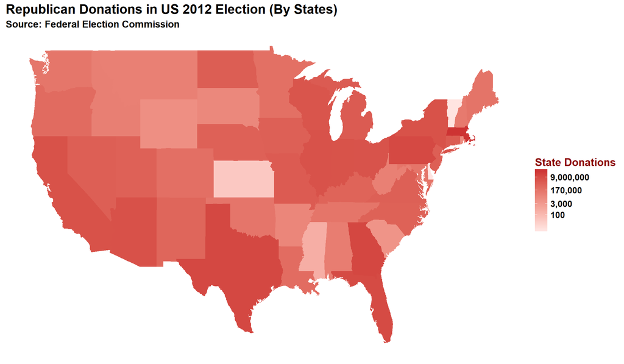

```r
# split the data of independent expenditure in the election cycle of 2012 by parties
# Sum up the contribution by state
candidate_contributions_2012_rep <- candidate_contributions_2012 %>%
   filter(cand_party_affiliation == "R") %>%
   group_by(cand_state) %>%
   summarize(state_donation = sum(total_donation, na.rm =TRUE))

candidate_contributions_2012_dem <- candidate_contributions_2012 %>%
   filter(cand_party_affiliation == "D") %>%
   group_by(cand_state) %>%
   summarize(state_donation = sum(total_donation, na.rm =TRUE))

# Apply the conversion function of state abbreviation to state full name to each of the party data set
candidate_contributions_2012_rep$cand_state <- lapply(candidate_contributions_2012_rep$cand_state, FUN = state_name)
candidate_contributions_2012_rep$cand_state <- as.character(candidate_contributions_2012_rep$cand_state)
candidate_contributions_2012_dem$cand_state <- lapply(candidate_contributions_2012_dem$cand_state, FUN = state_name)
candidate_contributions_2012_dem$cand_state <- as.character(candidate_contributions_2012_dem$cand_state)

# Change the 0 values in the data file to be 1 because later we will use the log transition. We convert 0 to 1 to avoid the undefining issue.
candidate_contributions_2012_rep$state_donation[candidate_contributions_2012_rep$state_donation == 0] <- 1
candidate_contributions_2012_dem$state_donation[candidate_contributions_2012_dem$state_donation == 0] <- 1

# get the states data from the map_data package
states <- map_data("state")

# Add another column named cand_state with same element as the column region
states$cand_state <- states$region

# Join the states data and contribution data files by cand_state
map_rep <- inner_join(states, candidate_contributions_2012_rep, by ="cand_state")
map_dem <- inner_join(states, candidate_contributions_2012_dem, by ="cand_state")


# Create the map for Republican
rep <- gplot(map_rep) +
      labs(title = "Republican Donations in US 2012 Election (By States)",
           subtitle = "Source: Federal Election Commission") +
      scale_fill_gradient(low="mistyrose1", high="brown3", trans = "log",
                          name = "State Donations", breaks = c(100,3000, 170000, 9000000),
                           labels = c("100","3,000", "170,000","9,000,000"))+
      theme(legend.title = element_text(colour="red4", size=15, face="bold"))

rep
```

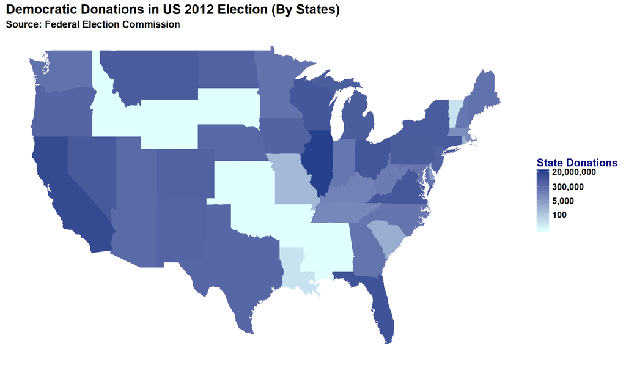

```r
# Create the map for Democratic
dem <- gplot(map_dem) +
      labs(title = "Democratic Donations in US 2012 Election (By States)",
           subtitle = "Source: Federal Election Commission") +
      scale_fill_gradient(low="lightcyan", high="royalblue4", trans = "log",
                          name = "State Donations", breaks = c(100,5000, 300000,20000000),
                          labels = c("100","5,000","300,000","20,000,000"))+
      theme(legend.title = element_text(colour="navy", size=15, face="bold"))

dem
```

### Discussion and Conclusion

- When the Transaction Doesn’t Fall into the Category of 24E

- Only Candidate in the Election

If a candidate is the only nominee in the election, then people has no incentive to contribute money to this candidate. For example, Terri Sewell was the only candidate to file for the Democratic nomination in 2012 in Alabama. Even though we can find her name and ID in the candidate data, there is no record of the independent expenditure for her in the contribution data.

- Term Limit

If a candidate has already served for two consecutive terms in the previous years, the candidate could not seek re-election due to the term limit. An example is Kenneth Corn, who served in the Oklahoma State Senate, representing District 4 from 2002 to 2010, but was not re-elected due to the term limit.

Based on the special cases discussed above and the complexity of the dataset, we shouldn’t assume that no data means that data is missing; instead, it shows how sometimes we just need to see the data just the way it is.

**The party inclination across states fluctuates in different election cycles depending on personal incentives, such as the background of running candidates.**

Here is a footnote for [Github](https://github.com/lucysz/sds192-mp2-1)